# Assignment 2 - Supervised learning

## Assignment 2 - Supervised Learning

IMPORT NECESSARY LIBRARIES

```python
import numpy as np
import pandas as pd
import matplotlib.pyplot as plt
import seaborn as sns

from sklearn.linear_model import LogisticRegression
from sklearn.naive_bayes import GaussianNB
from sklearn.neighbors import KNeighborsClassifier
from sklearn.metrics import confusion_matrix, classification_report, roc_auc_score, roc_curve,accuracy_score,auc
from sklearn.model_selection import train_test_split, GridSearchCV
from sklearn.preprocessing import MinMaxScaler, binarize
from sklearn.impute import SimpleImputer
import scipy.stats as stat
from math import sqrt
%matplotlib inline
```

## Q6. Load the data into a data-frame. The data-frame should have data and column description.

Note: Q1 onwards are covered after this.

Assuming the dataset is available in the same directory as the notebook and is named "Bank_Personal_Loan_Modelling.csv"

```python
bank_loan_df = pd.read_csv("Bank_Personal_Loan_Modelling.csv")
```

Adding column information and storing in HDF file

```python
bank_loan_df.col_description =   {"ID" : "Customer ID", "Age" : "Customer's age in completed years",
                        "Experience" : "#years of professional experience",
                        "Income" : "Annual income of the customer ($000)",
                        "ZIP Code" : "Home Address ZIP code.",
                        "Family" : "Family size of the customer",
                        "CCAvg" : "Avg. spending on credit cards per month ($000)",
                        "Education" : "Education Level. 1: Undergrad; 2: Graduate;3: Advanced/Professional",
                        "Mortgage" : "Value of house mortgage if any. ($000)",
                        "Personal Loan" : "Did this customer accept the personal loan offered in the last campaign?",
                        "Securities Account" : "Does the customer have a securities account with the bank?",
                        "CD Account" : "Does the customer have a certificate of deposit (CD) account with the bank?",
                        "Online" : "Does the customer use internet banking facilities?",
                        "Credit card" : "Does the customer use a credit card issued by UniversalBank?"}
```

Ensuring that the data frame contains column description </font>

```python
bank_loan_df.head(5)
```

|  | ID | Age | Experience | Income | ZIP Code | Family | CCAvg | Education | Mortgage | Personal Loan | Securities Account | CD Account | Online | CreditCard |
| --- | --- | --- | --- | --- | --- | --- | --- | --- | --- | --- | --- | --- | --- | --- |
| 0 | 1 | 25 | 1 | 49 | 91107 | 4 | 1.6 | 1 | 0 | 0 | 1 | 0 | 0 | 0 |
| 1 | 2 | 45 | 19 | 34 | 90089 | 3 | 1.5 | 1 | 0 | 0 | 1 | 0 | 0 | 0 |
| 2 | 3 | 39 | 15 | 11 | 94720 | 1 | 1.0 | 1 | 0 | 0 | 0 | 0 | 0 | 0 |
| 3 | 4 | 35 | 9 | 100 | 94112 | 1 | 2.7 | 2 | 0 | 0 | 0 | 0 | 0 | 0 |
| 4 | 5 | 35 | 8 | 45 | 91330 | 4 | 1.0 | 2 | 0 | 0 | 0 | 0 | 0 | 1 |

Storing metadata information about the dataframe </font>

```python
with pd.HDFStore("Bank Loan.h5") as bank_loan_store:
    bank_loan_store.put("df", bank_loan_df)
    bank_loan_store.get_storer("df").attrs.col_description = bank_loan_df.col_description
```

```python
with pd.HDFStore("Bank Loan.h5") as bank_loan_store:
    bank_loan_df = bank_loan_store.get("df")
    bank_loan_df.col_description = bank_loan_store.get_storer("df").attrs.col_description
```

```python
bank_loan_df.col_description
```

```
{'ID': 'Customer ID',
 'Age': "Customer's age in completed years",
 'Experience': '#years of professional experience',
 'Income': 'Annual income of the customer ($000)',
 'ZIP Code': 'Home Address ZIP code.',
 'Family': 'Family size of the customer',
 'CCAvg': 'Avg. spending on credit cards per month ($000)',
 'Education': 'Education Level. 1: Undergrad; 2: Graduate;3: Advanced/Professional',
 'Mortgage': 'Value of house mortgage if any. ($000)',
 'Personal Loan': 'Did this customer accept the personal loan offered in the last campaign?',
 'Securities Account': 'Does the customer have a securities account with the bank?',
 'CD Account': 'Does the customer have a certificate of deposit (CD) account with the bank?',
 'Online': 'Does the customer use internet banking facilities?',
 'Credit card': 'Does the customer use a credit card issued by UniversalBank?'}
```

We successfully stored metadata about the dataframe and retrieved it </font>

## Q1. Univariate analysis

```python
bank_loan_df.describe()
```

|  | ID | Age | Experience | Income | ZIP Code | Family | CCAvg | Education | Mortgage | Personal Loan | Securities Account | CD Account | Online | CreditCard |
| --- | --- | --- | --- | --- | --- | --- | --- | --- | --- | --- | --- | --- | --- | --- |
| count | 5000.000000 | 5000.000000 | 5000.000000 | 5000.000000 | 5000.000000 | 5000.000000 | 5000.000000 | 5000.000000 | 5000.000000 | 5000.000000 | 5000.000000 | 5000.00000 | 5000.000000 | 5000.000000 |
| mean | 2500.500000 | 45.338400 | 20.104600 | 73.774200 | 93152.503000 | 2.396400 | 1.937938 | 1.881000 | 56.498800 | 0.096000 | 0.104400 | 0.06040 | 0.596800 | 0.294000 |
| std | 1443.520003 | 11.463166 | 11.467954 | 46.033729 | 2121.852197 | 1.147663 | 1.747659 | 0.839869 | 101.713802 | 0.294621 | 0.305809 | 0.23825 | 0.490589 | 0.455637 |
| min | 1.000000 | 23.000000 | -3.000000 | 8.000000 | 9307.000000 | 1.000000 | 0.000000 | 1.000000 | 0.000000 | 0.000000 | 0.000000 | 0.00000 | 0.000000 | 0.000000 |
| 25% | 1250.750000 | 35.000000 | 10.000000 | 39.000000 | 91911.000000 | 1.000000 | 0.700000 | 1.000000 | 0.000000 | 0.000000 | 0.000000 | 0.00000 | 0.000000 | 0.000000 |
| 50% | 2500.500000 | 45.000000 | 20.000000 | 64.000000 | 93437.000000 | 2.000000 | 1.500000 | 2.000000 | 0.000000 | 0.000000 | 0.000000 | 0.00000 | 1.000000 | 0.000000 |
| 75% | 3750.250000 | 55.000000 | 30.000000 | 98.000000 | 94608.000000 | 3.000000 | 2.500000 | 3.000000 | 101.000000 | 0.000000 | 0.000000 | 0.00000 | 1.000000 | 1.000000 |
| max | 5000.000000 | 67.000000 | 43.000000 | 224.000000 | 96651.000000 | 4.000000 | 10.000000 | 3.000000 | 635.000000 | 1.000000 | 1.000000 | 1.00000 | 1.000000 | 1.000000 |

## OBSERVATIONS

1. customerID can be dropped. It adds no value.
2. Age column looks fine as the min and max are in acceptable ranges
3. Experience column has some outliers at the negative end and will need correction
4. Income looks acceptable as the max is in line. However the minimum is just 8000 dollars. We might need to inspect this
5. Zip codes will be evaluated to figure out their value
6. Family size looks fine
7. Average spending on credit cards is zero in some cases and may need a review
8. Education and Mortage columns look fine
9. Personal Loan, Securities Account, Personal Loan, CD Account, Online and Credit card details also look in line.

</font>

```python
bank_loan_df.info()
```

```
<class 'pandas.core.frame.DataFrame'>
Int64Index: 5000 entries, 0 to 4999
Data columns (total 14 columns):
ID                    5000 non-null int64
Age                   5000 non-null int64
Experience            5000 non-null int64
Income                5000 non-null int64
ZIP Code              5000 non-null int64
Family                5000 non-null int64
CCAvg                 5000 non-null float64
Education             5000 non-null int64
Mortgage              5000 non-null int64
Personal Loan         5000 non-null int64
Securities Account    5000 non-null int64
CD Account            5000 non-null int64
Online                5000 non-null int64
CreditCard            5000 non-null int64
dtypes: float64(1), int64(13)
memory usage: 585.9 KB
```

```python
print("ID Count:", bank_loan_df["ID"].nunique())
print("ZIP Count:", bank_loan_df["ZIP Code"].nunique())
```

```
ID Count: 5000
ZIP Count: 467
```

We drop both these columns as they have too many individual levels and do not contribute to the overall outcome.

```python
bank_loan_df = bank_loan_df.drop(["ID","ZIP Code"], axis = 1)
```

```python
bank_loan_df.isnull().sum()
```

```
Age                   0
Experience            0
Income                0
Family                0
CCAvg                 0
Education             0
Mortgage              0
Personal Loan         0
Securities Account    0
CD Account            0
Online                0
CreditCard            0
dtype: int64
```

Plotting distributions of all the columns except personal loans </font>

```
array([[<matplotlib.axes._subplots.AxesSubplot object at 0x000001D4B11B1358>,
      dtype=object)
```

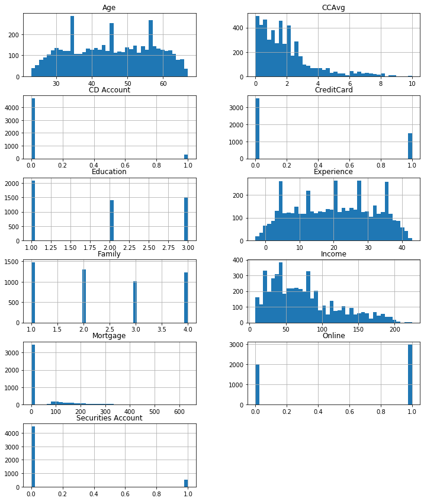

```python
bank_loan_df.drop("Personal Loan",axis = 1).hist(stacked = False, bins = 40, figsize = (12,30), layout = (12,2))
```

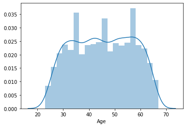

```python
sns.distplot(bank_loan_df["Age"], bins = 20)
```

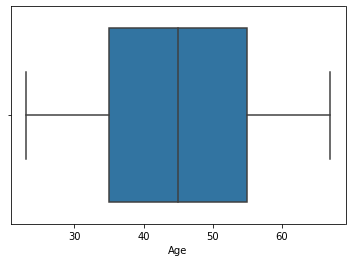

```python
sns.boxplot(bank_loan_df["Age"])
```

```python
np.percentile(bank_loan_df["Age"], [0,25,50,75,100])
```

```
array([23., 35., 45., 55., 67.])
```

## OBSERVATIONS

</font>

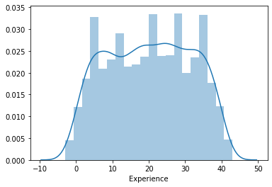

```python
sns.distplot(bank_loan_df["Experience"], bins = 20)
```

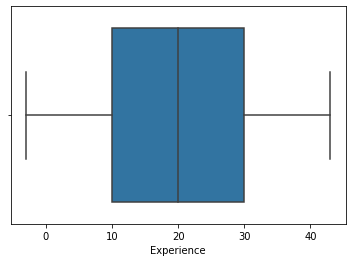

```python
sns.boxplot(bank_loan_df["Experience"])
```

```python
np.percentile(bank_loan_df["Experience"], [0,25,50,75,100])
```

```
array([-3., 10., 20., 30., 43.])
```

## OBSERVATIONS

```python
bank_loan_df[bank_loan_df["Experience"] < 0]["Experience"].count()/ bank_loan_df["Experience"].count()
```

```
0.0104
```

Number of rows with incorrect experience(Negative) are around 1%. However, instead of dropping them, we will treat them

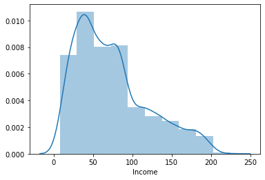

```python
sns.distplot(bank_loan_df["Income"], bins = 10)
```

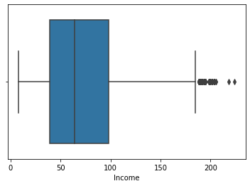

```python
sns.boxplot(bank_loan_df["Income"])
```

```python
np.percentile(bank_loan_df["Income"], [0,25,50,75,100])
```

```
array([  8.,  39.,  64.,  98., 224.])
```

```python
z_critical = 3
z = np.abs(stat.zscore(bank_loan_df[["Income"]]))
bank_loan_df[z>z_critical]
```

|  | Age | Experience | Income | Family | CCAvg | Education | Mortgage | Personal Loan | Securities Account | CD Account | Online | CreditCard |
| --- | --- | --- | --- | --- | --- | --- | --- | --- | --- | --- | --- | --- |
| 3896 | 48 | 24 | 224 | 2 | 6.67 | 1 | 0 | 0 | 0 | 1 | 1 | 1 |
| 4993 | 45 | 21 | 218 | 2 | 6.67 | 1 | 0 | 0 | 0 | 0 | 1 | 0 |

## OBSERVATIONS

1. In this case we see two outliers. Incomes of 224000, 218000. This means that the income of 8000, though extremely low is not an outlier to be treated

</font>

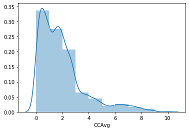

```python
sns.distplot(bank_loan_df["CCAvg"], bins = 10)
```

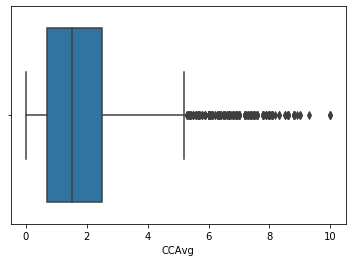

```python
sns.boxplot(bank_loan_df["CCAvg"])
```

```python
np.percentile(bank_loan_df["CCAvg"], [0,25,50,75,100])
```

```
array([ 0. ,  0.7,  1.5,  2.5, 10. ])
```

```python
z_critical = 3
z = np.abs(stat.zscore(bank_loan_df[["CCAvg"]]))
bank_loan_df[z>z_critical]
```

|  | Age | Experience | Income | Family | CCAvg | Education | Mortgage | Personal Loan | Securities Account | CD Account | Online | CreditCard |
| --- | --- | --- | --- | --- | --- | --- | --- | --- | --- | --- | --- | --- |
| 9 | 34 | 9 | 180 | 1 | 8.9 | 3 | 0 | 1 | 0 | 0 | 0 | 0 |
| 18 | 46 | 21 | 193 | 2 | 8.1 | 3 | 0 | 1 | 0 | 0 | 0 | 0 |
| 55 | 41 | 17 | 139 | 2 | 8.0 | 1 | 0 | 0 | 0 | 0 | 1 | 0 |
| 131 | 58 | 34 | 149 | 4 | 7.2 | 2 | 0 | 1 | 0 | 1 | 1 | 1 |
| 145 | 59 | 35 | 124 | 1 | 7.4 | 1 | 0 | 0 | 0 | 0 | 0 | 1 |
| ... | ... | ... | ... | ... | ... | ... | ... | ... | ... | ... | ... | ... |
| 4652 | 38 | 12 | 184 | 3 | 8.0 | 1 | 0 | 1 | 0 | 0 | 1 | 0 |
| 4679 | 26 | 0 | 161 | 2 | 7.2 | 1 | 0 | 0 | 0 | 0 | 0 | 0 |
| 4782 | 26 | 0 | 150 | 2 | 7.2 | 1 | 0 | 0 | 0 | 0 | 0 | 1 |
| 4911 | 46 | 22 | 153 | 2 | 7.5 | 1 | 0 | 0 | 0 | 0 | 0 | 0 |
| 4937 | 33 | 8 | 162 | 1 | 8.6 | 1 | 0 | 0 | 0 | 1 | 1 | 1 |

121 rows × 12 columns

## OBSERVATIONS

1. ~2.4% of the Credit Card average bill are outside the 3 Sigma Score and can be considered outliers
2. The median spend is 1500 dollars per month, while the maximum is 10000 dollars per month </font>

```python
bank_loan_df[bank_loan_df["CCAvg"]>0]["CCAvg"].mean() * 1000 #Excludes those who dont use a credit card (no spend)
```

```
1979.9121373109986
```

```python
bank_loan_df["CCAvg"].mean() * 1000
```

```
1937.9380000000053
```

## OBSERVATIONS

1. The average Credit card spending per month is 1938$
2. The spending of people who actually use a credit card is 1980$
3. The mean is significantly larger than the median as there are outliers to the right.

</font>

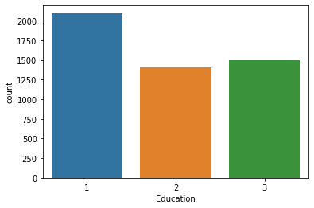

```python
sns.countplot(bank_loan_df["Education"])
```

```python
print ("Education 1:", (bank_loan_df[bank_loan_df["Education"]== 1]["Education"].count()/bank_loan_df["Education"].count()))
print ("Education 2:", (bank_loan_df[bank_loan_df["Education"]== 2]["Education"].count()/bank_loan_df["Education"].count()))
print ("Education 3:", (bank_loan_df[bank_loan_df["Education"]== 3]["Education"].count()/bank_loan_df["Education"].count()))
```

```
Education 1: 0.4192
Education 2: 0.2806
Education 3: 0.3002
```

## OBSERVATION:

1. Around 41% of the bank's customers are undergrads
2. 28% grads
3. 30% post grads/advanced </font>

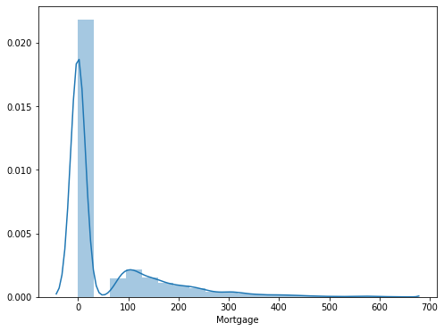

```python
plt.figure(figsize = (8,6))
sns.distplot(bank_loan_df["Mortgage"], bins = 20)
```

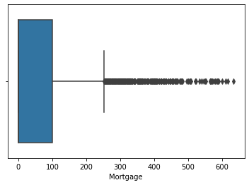

```python
sns.boxplot(bank_loan_df["Mortgage"])
```

```python
np.percentile(bank_loan_df["Mortgage"], [0,25,50,75,100])
```

```
array([  0.,   0.,   0., 101., 635.])
```

```python
z_critical = 3 # calculating outliers outside 3 sigma range
z = np.abs(stat.zscore(bank_loan_df[["Mortgage"]]))
print(bank_loan_df[z>z_critical]["Mortgage"].min())
bank_loan_df[z>z_critical]
```

```
364
```

|  | Age | Experience | Income | Family | CCAvg | Education | Mortgage | Personal Loan | Securities Account | CD Account | Online | CreditCard |
| --- | --- | --- | --- | --- | --- | --- | --- | --- | --- | --- | --- | --- |
| 42 | 32 | 7 | 132 | 4 | 1.1 | 2 | 412 | 1 | 0 | 0 | 1 | 0 |
| 59 | 31 | 5 | 188 | 2 | 4.5 | 1 | 455 | 0 | 0 | 0 | 0 | 0 |
| 119 | 32 | 7 | 112 | 1 | 4.6 | 1 | 366 | 0 | 0 | 0 | 0 | 0 |
| 288 | 44 | 19 | 172 | 2 | 4.3 | 3 | 391 | 1 | 1 | 1 | 1 | 0 |
| 303 | 49 | 25 | 195 | 4 | 3.0 | 1 | 617 | 1 | 0 | 0 | 0 | 0 |
| ... | ... | ... | ... | ... | ... | ... | ... | ... | ... | ... | ... | ... |
| 4672 | 52 | 26 | 180 | 1 | 1.7 | 1 | 550 | 0 | 0 | 0 | 1 | 0 |
| 4698 | 48 | 22 | 162 | 3 | 1.4 | 1 | 400 | 1 | 0 | 0 | 0 | 0 |
| 4812 | 29 | 4 | 184 | 4 | 2.2 | 3 | 612 | 1 | 0 | 0 | 1 | 0 |
| 4842 | 49 | 23 | 174 | 3 | 4.6 | 2 | 590 | 1 | 0 | 0 | 0 | 0 |
| 4859 | 34 | 8 | 165 | 1 | 7.0 | 3 | 541 | 1 | 0 | 0 | 0 | 0 |

105 rows × 12 columns

```python
print(bank_loan_df[bank_loan_df["Mortgage"]>0]["Mortgage"].count()/bank_loan_df["Mortgage"].count())
```

```
0.3076
```

## OBSERVATION

1. 30% of the bank's customers have mortgages
2. Around 2.1% Mortgages are outside the 3 Sigma Score and can be considered outliers
3. Mortgages above 364000 are considered outliers as per the above definition. There are no left sided outliers as the dataset is biased towards the right
4. The median mortgage is 0 </font>

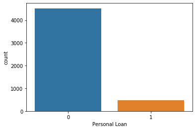

```python
sns.countplot(bank_loan_df["Personal Loan"])
```

```python
bank_loan_df[bank_loan_df["Personal Loan"]==1]["Personal Loan"].count()/bank_loan_df["Personal Loan"].count()
```

```
0.096
```

## OBSERVATION:

1. Around 10% of the bank users are Personal Loan holders

   </font>

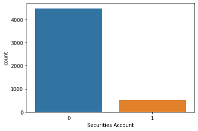

```python
sns.countplot(bank_loan_df["Securities Account"])
```

```python
bank_loan_df[bank_loan_df["Securities Account"]==1]["Securities Account"].count()/bank_loan_df["Securities Account"].count()
```

```
0.1044
```

## OBSERVATION

1. Around 10% of the bank users are securities account holders </font>

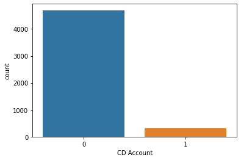

```python
sns.countplot(bank_loan_df["CD Account"])
```

```python
bank_loan_df[bank_loan_df["CD Account"]==1]["CD Account"].count()/bank_loan_df["CD Account"].count()
```

```
0.0604
```

## OBSERVATION:

1. Around 6% of the bank users have a Certificate of Deposit account </font>

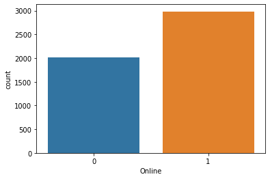

```python
sns.countplot(bank_loan_df["Online"])
```

```python
bank_loan_df[bank_loan_df["Online"]==1]["Online"].count()/bank_loan_df["Online"].count()
```

```
0.5968
```

## OBSERVATION

1. Around 60% of the bank users are online users </font>

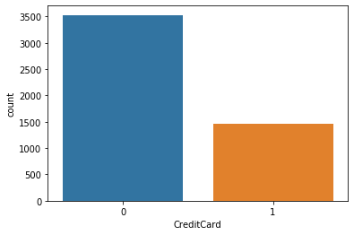

```python
sns.countplot(bank_loan_df["CreditCard"])
```

```python
bank_loan_df[bank_loan_df["CreditCard"]==1]["CreditCard"].count()/bank_loan_df["CreditCard"].count()
```

```
0.294
```

## OBSERVATION

1. Around 30% of the bank users are credit card holders </font>

## Q2. Multivariate Analysis

We use the pair plot to map all variables against the personal loan column

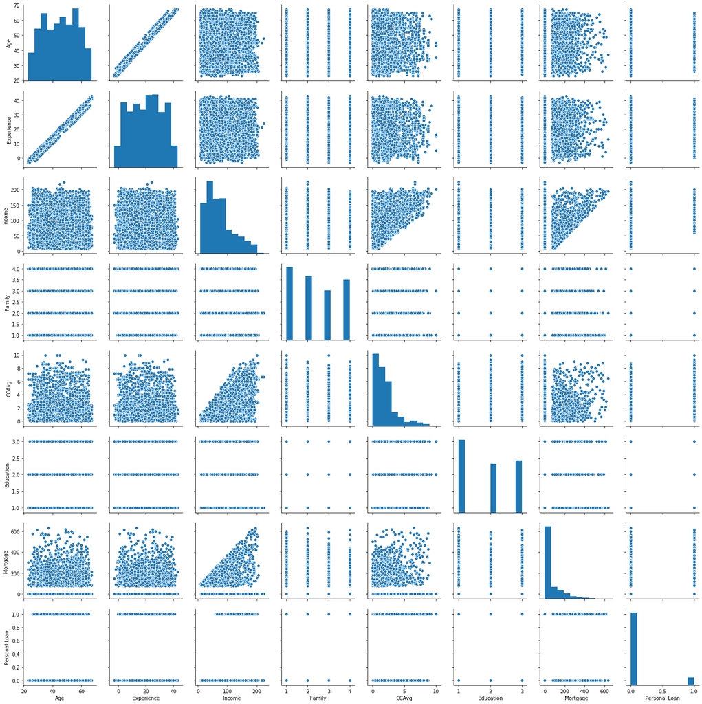

```python
sns.pairplot(bank_loan_df.iloc[:,0:8])
```

## OBSERVATIONS

We shall examine these trends in more detail through individual plots

</font>

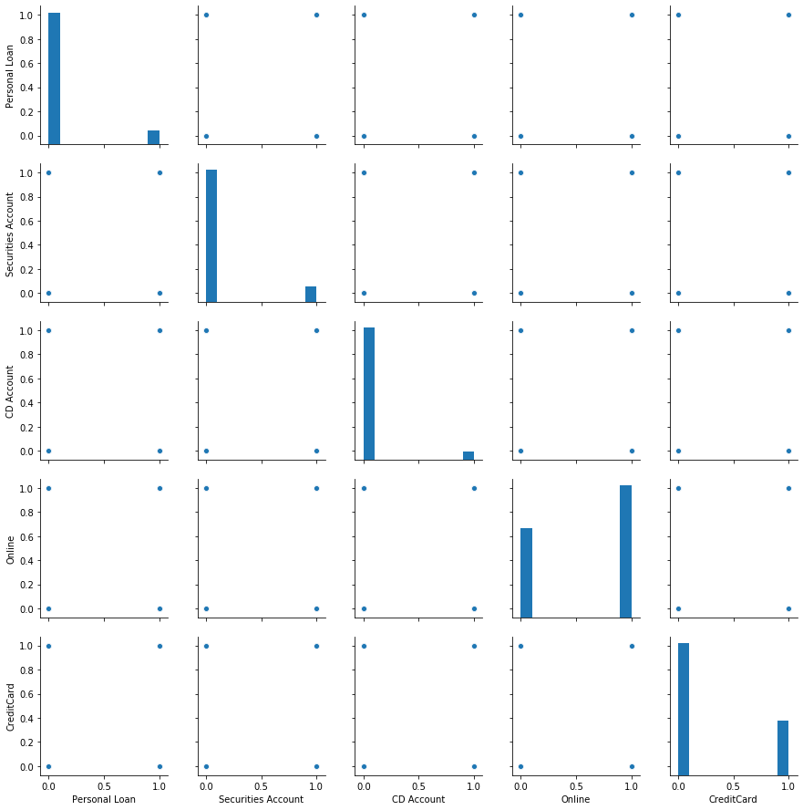

```python
sns.pairplot(bank_loan_df.iloc[:,7:])
```

## OBSERVATIONS

1. There seems to be no clear pattern visible in this section of the pairplot </font>

```
(0, 16)
```

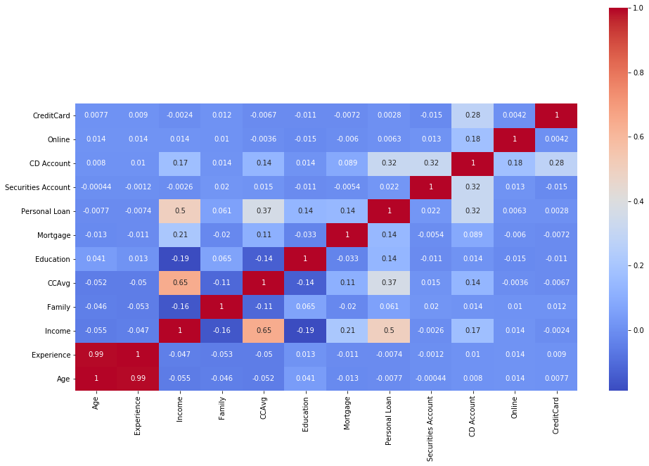

```python
plt.figure(figsize = (16,10))
sns.heatmap(bank_loan_df.corr(), annot = True, cmap = "coolwarm")
ax=plt.gca()
ax.set_ylim(0, 16)
```

## OBSERVATIONS

1. Age and Experience are highly correlated. consequently, we will have to drop one of them later to ensure our machine learning analysis proceeds correctly
2. We observe very strong correlations between income and Credit card costs during a month (CCAvg) and an observable correlation between income and Mortgages
3. Education and Family negatively influence CCAvg and Mortgages, but have a mildly positive correlation with Personal Loans
4. Apart from experience and age, all factors positively correlate with Personal Loans
5. CCAvg, Income and CD account have the strongest correlation with having a personal loan </font>

## Q3. Strategies to address the different data challenges such as data pollution, outliers and missing values

Done after Q7 to preserve variables for statistical analysis

</font>

## Q4. Target Column Distribution - In our case 'Personal Loan' is Target Variable

## Graph: Personal loan distribution

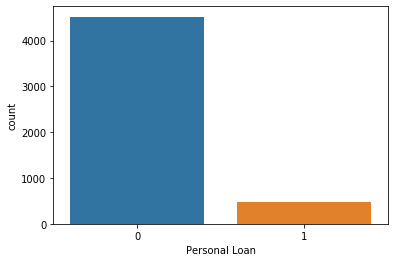

```python
sns.countplot(bank_loan_df["Personal Loan"])
```

```python
bank_loan_df[bank_loan_df["Personal Loan"] == 1]["Personal Loan"].count()/bank_loan_df["Personal Loan"].count()
```

```
0.096
```

## OBSERVATIONS

Only 9.6% people have taken a personal loan.

</font>

## Q5. Data Distribution of 'Personal Loan' across all variables

## Graph: Personal loan vs Income, Hued by Online

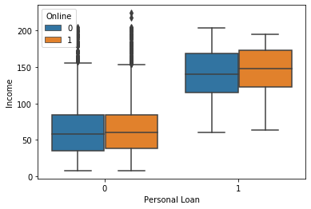

```python
sns.boxplot(x = "Personal Loan", y = "Income", hue = "Online", data = bank_loan_df)
```

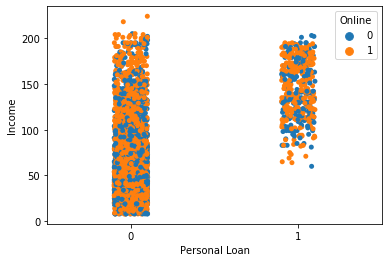

```python
sns.stripplot(x = "Personal Loan", y = "Income", hue = "Online", data = bank_loan_df)
```

## OBSERVATIONS

1. Personal loan takers have a generally higher median income over people who dont take personal loans
2. Online users have marginally greater income as compared to non online users

</font>

## Graph: Personal loan vs Income, Hued by Securities Account

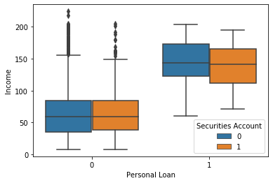

```python
sns.boxplot(x = "Personal Loan", y = "Income", hue = "Securities Account", data = bank_loan_df)
```

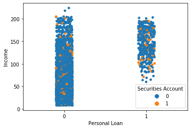

```python
sns.stripplot(x = "Personal Loan", y = "Income", hue = "Securities Account", data = bank_loan_df)
```

## OBSERVATIONS

Securities Account holders have marginally lower income as compared to people who dont own securities accounts </font>

## Graph: Personal loan vs Income, Hued by CD Account

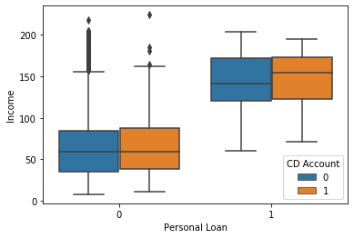

```python
sns.boxplot(x = "Personal Loan", y = "Income", hue = "CD Account", data = bank_loan_df)
```

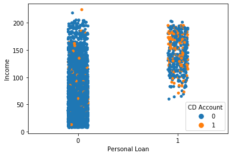

```python
sns.stripplot(x = "Personal Loan", y = "Income", hue = "CD Account", data = bank_loan_df)
```

## OBSERVATIONS

CD Account holders are more likely to take a personal loan </font>

## Graph: Personal loan vs Income, Hued by Credit Card

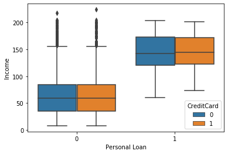

```python
sns.boxplot(x = "Personal Loan", y = "Income", hue = "CreditCard", data = bank_loan_df)
```

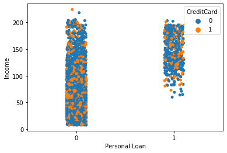

```python
sns.stripplot(x = "Personal Loan", y = "Income", hue = "CreditCard", data = bank_loan_df)
```

## OBSERVATIONS

No Additional Observations to make

</font>